# Univariate Analysis

## Objective

Analysing the biodiversity measurement of rare species in various location across the United Kingdom over specific time periods.

There are 11 species, I took five of them to analyse whether these species have an association with the location they have been found.

Bees, Hoverflies, Isopods, Ladybirds, Grasshoppers & Crickets

### Summary Table

```r
summary # Summary and 20% winsorized mean for my allocated species
```

```
##                Taxi_group         Min         1st Q       Median Mean
## 1                    Bees 0.104734577    0.37446198 0.6293967935 0.68
## 2              Hoverflies  0.41749503 0.65873069325  0.752865079 0.75
## 3                 Isopods 0.177033493 0.46249245125  0.686567164 0.65
## 4               Ladybirds 0.115107914 0.60435681325 0.7499396455 0.74
## 5 Grasshoppers_._Crickets  0.07079646   0.433628319 0.5572420745 0.59
##           3rd Q         Max Twenty_p_win_mean
## 1   0.907474601 3.309859155              0.64
## 2 0.83053145325           1              0.76
## 3  0.8596014495           1              0.65
## 4 0.86799952525  1.37755102              0.74
## 5 0.75828590575 1.324137931              0.59
```

This table consists of my allocated five species named Bees, Hoverflies, Isopods, Ladybirds, Grasshoppers & Crickets, across various dominant land class in Wales and calculated summary statistics, and 20% winsorized mean.

It seems Bees have higher density in some places which indicates that there may be a chance to expand its colony. The winsorised mean can be calculated by trimming 20% of upper and lower tail values with the prior and following values of each dataset. Both mean values were rounded to 2 decimal points, then observed the difference between winsorised mean and the true mean. Except for Bees and Hoverflies, the difference is zero for the rest of the species. The basic purpose of calculating winsorized mean is to find if there is any impact by outliers or extreme values. In this case, the winsorised mean is quite different from the true mean for bees and hoverflies, indicating that extreme values have a substantial impact on the mean. Also, it is similar to the true mean for the rest of the species, it suggests that the data distribution is relatively symmetric and free from extreme values. In my opinion, these are rare creatures and they somehow help to improve biodiversity. So there isn’t any problem if they find in required density in every place.

### Correlation Table

```r
correlation # Correlation table for each species
```

```
##                          Bees Hoverflies Isopods Ladybirds
## Bees                     1.00       0.06   -0.04      0.37
## Hoverflies               0.06       1.00    0.37      0.41
## Isopods                 -0.04       0.37    1.00      0.07
## Ladybirds                0.37       0.41    0.07      1.00
## Grasshoppers_._Crickets  0.24       0.43    0.57      0.25
##                         Grasshoppers_._Crickets
## Bees                                       0.24
## Hoverflies                                 0.43
## Isopods                                    0.57
## Ladybirds                                  0.25
## Grasshoppers_._Crickets                    1.00
```

The linear relationship between each taxonomic group lies between the weak and the moderate level.

It shows if one species increases/decreases there isn’t any notable change in other species. Isopods and Grasshoppers & Crickets reported the highest correlation coefficient value of 0.57 (positive correlation) among all other combinations.

### Boxplot

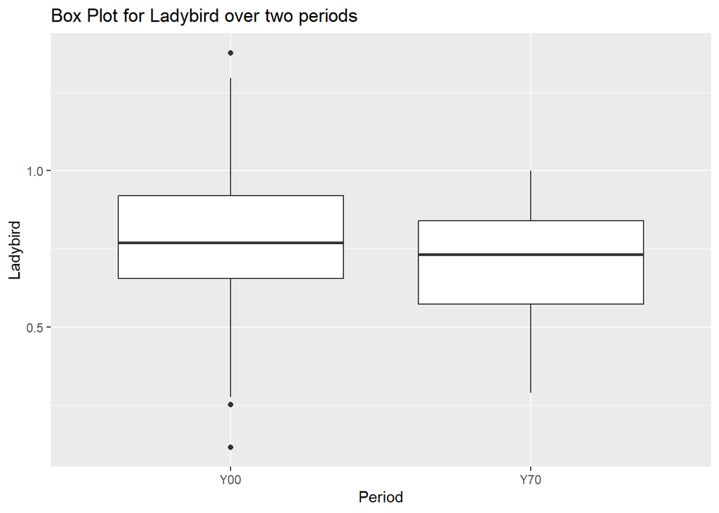

## Hypothesis Test

### Kolmogorov-Smirnov Test

The two-sample KS test was performed using two samples to find whether the samples come from the same distribution.

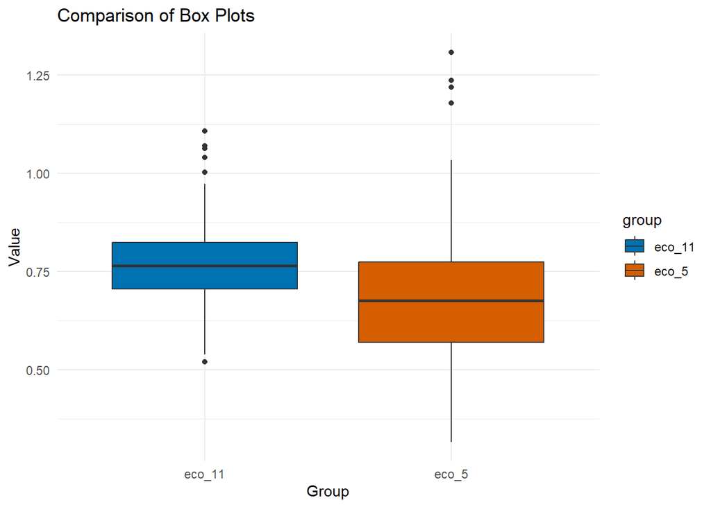

From the two box plots, it’s obvious that they did not came from the same distribution.

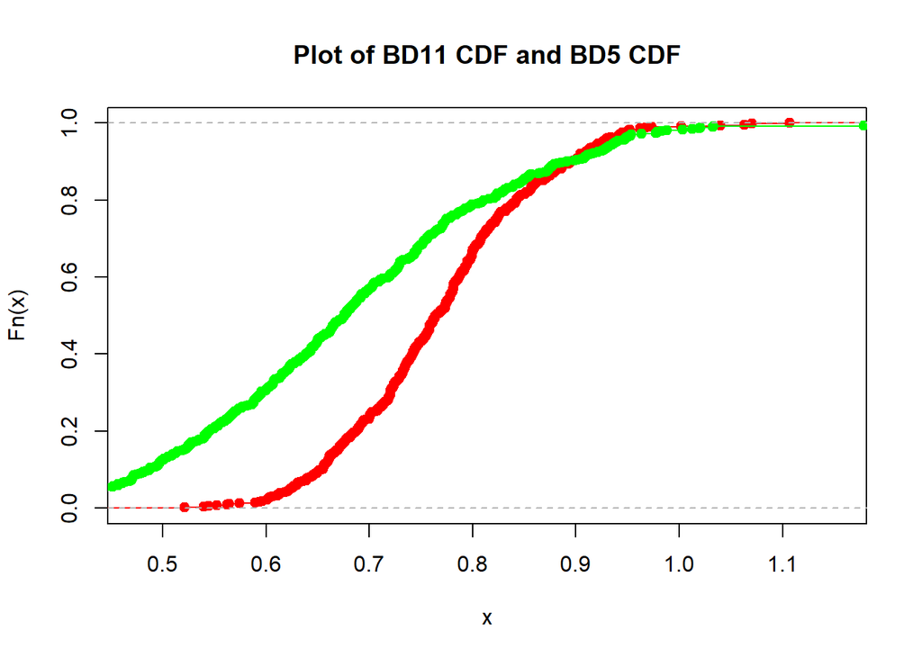

The cumulative distribution function represents the dissimilarity between the two data sets. Red refers to the CDF of ecological status 11 and green refers to the CDF of ecological status 5. It is apparent, that the two data sets did not overlap consistently. Therefore, these two distributions are dissimilar.

```r
ks.test(eco_status_11$value, eco_status_5$value)
```

```
##
##  Asymptotic two-sample Kolmogorov-Smirnov test
##
## data:  eco_status_11$value and eco_status_5$value
## D = 0.34601, p-value < 2.2e-16
## alternative hypothesis: two-sided
```

Here, the two samples are BD11’s CDF and BD5’s CDF. The test produced a p-value smaller than the significant level (0.05) and indicates overwhelming evidence against the null hypothesis. Therefore, the two data sets come from different distributions. The D-statistics is 0.34601, representing level of dissimilarity between the two distributions.

### t-test

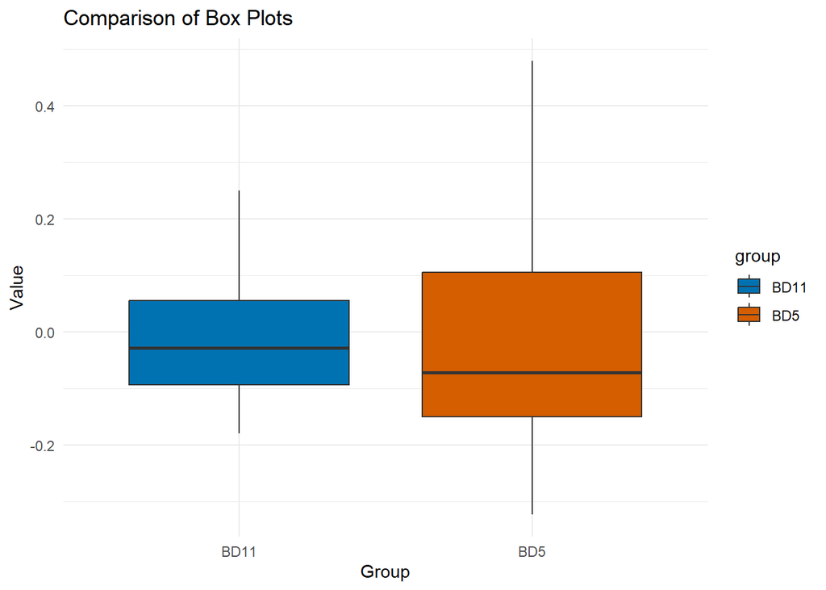

Boxplots for BD5 change and BD11 change, it seems the median of these two are quite close. So, I assumed that the null hypothesis of both data sets’ mean values are more like same.

```r
t.test(BD5_change$value, mu = avg)
```

```
##
##  One Sample t-test
##
## data:  BD5_change$value
## t = -1.0958, df = 262, p-value = 0.2742
## alternative hypothesis: true mean is not equal to -0.01589769
## 95 percent confidence interval:
##  -0.047644242 -0.006851741
## sample estimates:
##   mean of x
## -0.02724799
```

Therefore, here I performed a one-sample t-test and it provides a p-value of 0.274 larger than the threshold level (0.05) and implies that they don’t have sufficient evidence to reject the null hypothesis. In other words, it has enough evidence to claim that the BD5 change mean is equal to the BD11 change mean.

The population mean (mean of BD11 change) is -0.01589769 and the sample mean (mean of BD5 change) is - 0.02724799.

The 95% confidence interval (-0.047644242, -0.006851741) provides the range of possible values for the true mean and suggests that the data is consistent with the possibility that the true mean of both data sets are the same.

## Contingency Table and Independent Table

### Contingency Table (Observed Table)

```r
table_up_down
```

```
##       BD5UP
## BD11UP DOWN  UP
##   DOWN  162   1
##   UP      6  94
```

### Independent Table (Expected Table)

```r
independent_table
```

```
##      DOWN  UP
## DOWN  104  59
## UP     64  36
```

### Likelihood-ratio Test

```r
GTest(table_up_down)
```

```
##
##  Log likelihood ratio (G-test) test of independence without correction
##
## data:  table_up_down
## G = 286.49, X-squared df = 1, p-value < 2.2e-16
```

The p-value associated with the G-test is smaller than significant level for the contingency table (table up down / observed table). It indicates extant evidence against the null hypothesis of independence. In other words, there is a significant association or dependence between BD11up and BD5up. The larger G-value (286.49) provided robust evidence against independence. When comparing the proportions of increase in BD5 and BD11 from the contingency table, they are more likely to increase.

### Odds-ratio

```r
odds_ratio
```

```
## [1] 2538
```

### Sensitivity

```r
sensitivity
```

```
##        UP
## 0.9894737
```

Sensitivity is used to measure the true positive rate out of all positive outcomes. In this case, sensitivity is 0.9894737 and will predict true positive cases 99% accurately.

### Specificity

```r
specificity
```

```
##      DOWN
## 0.9642857
```

Specificity is used to measure the true negative rate out of all negative outcomes. In this case, specificity is 0.9642857 and will predict true negative cases 96% accurately.

### Youden’s Index

```r
youden
```

```
##        UP
## 0.9537594
```

Youden’s index indicates the overall performance of a model. In this case, Youden’s index is 0.9537594.

## Linear regression

### Simple linear regression

```r
summary(l_mod)
```

```
##
## Call:
## lm(formula = BD1$Carabids ~ BD5$eco_status_5, y = T)
##
## Residuals:
##      Min       1Q   Median       3Q      Max
## -0.51409 -0.13721  0.03447  0.13888  0.34411
##
## Coefficients:
##                  Estimate Std. Error t value Pr(>|t|)
## (Intercept)       0.18504    0.03617   5.116 4.38e-07 ***
## BD5$eco_status_5  0.65021    0.05166  12.587  < 2e-16 ***
## ---
## Signif. codes:  0 '***' 0.001 '**' 0.01 '*' 0.05 '.' 0.1 ' ' 1
##
## Residual standard error: 0.1827 on 524 degrees of freedom
## Multiple R-squared:  0.2322, Adjusted R-squared:  0.2307
## F-statistic: 158.4 on 1 and 524 DF,  p-value: < 2.2e-16
```

Carabids has been taken as a responsive variable and ecological status 5 (mean of allocated five variables) as the predictor variable and calculated simple linear regression. The estimated intercepting value is 0.18504, this means the y value is 0.18504 when x = 0. The estimated slope value is 0.65021, this means the y value will be this much when x changes one unit.

```r
cor(l_mod$fitted.values, l_mod$y)
```

```
## [1] 0.481824
```

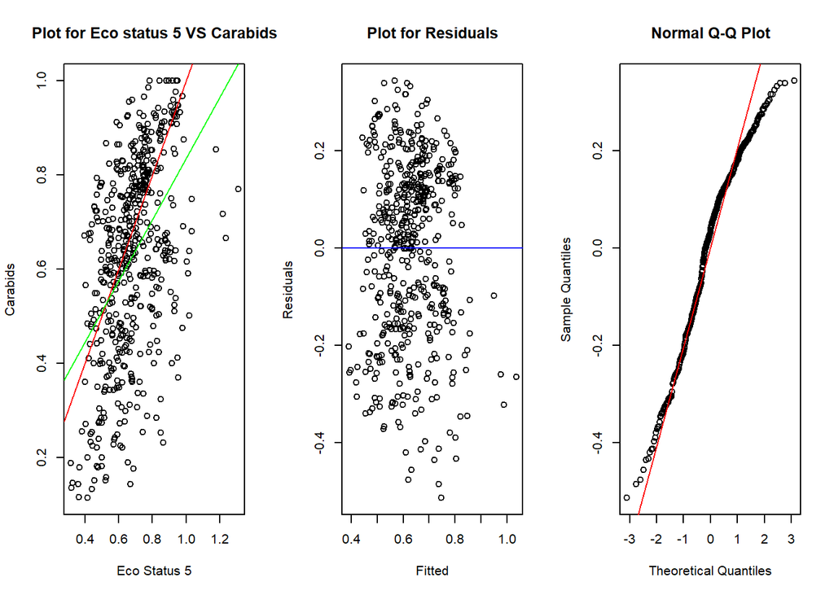

From the first plot, the red line refers zero line and the green line refers to model-fitted line. All the data points are spread all over the graph. When observing the data point density, it roughly follows the red line and can see some abnormal patterns and inconsistencies. The green has been plotted to adjust the data point variations. Also, few values deviated from both lines, ensuring the presence of outliers. It may affect the analysis outcome negatively.

The plot for residuals is the difference between the actual data set and the model-fitted value. When noticing the data points, though some values are closer to the line, most of the values don’t closely follow the line. Therefore, we can’t precisely say that the residuals are normally distributed. Also, the pattern indicates biasing at one side and the deviated values imply the potential outliers.

The Q-Q plot for residuals seems to be fairly distributed besides having a lighter tail on both sides. Even though the slope is significant, the plot did not clarify whether the data set is normally distributed. Therefore, it indicates the importance of cleansing extreme values and identifying specific patterns before analysing.

### Multiple linear regression

```r
AIC(mlr_mod); cor(mlr_mod$fitted.values, mlr_mod$y)
```

```
## [1] -490.6621
```

```
## [1] 0.6941984
```

Performed a multiple linear regression with the same response variable as it is in the simple linear regression with allocated five species as a predictor variable. While observing the p-value for each predictor variable. Out of other variables, Ladybirds produced a slightly higher p-value depicting that it hasn’t any considerable association with the response variable. The overall p-value is less than the threshold point, the adjusted R-squared value is 0.4769, the correlation coefficient value of 0.6941984, and the AIC of -490.6621.

```r
AIC(mlr_mod_red); cor(mlr_mod_red$fitted.values, mlr_mod_red$y)
```

```
## [1] -491.2556
```

```
## [1] 0.6931985
```

Due to possessing a higher p-value, I dropped Ladybird from the predictor variables and performed another linear regression. The computed overall p-value, adjusted R squared value as same as the previous one, and produced pretty much smaller AIC value (-491.2556), and correlation coefficient value (0.6931985).

```r
summary(mlr_mod_int)
```

```
##
## Call:
## lm(formula = BD1$Carabids ~ Bees + Hoverflies + Isopods + Grasshoppers_._Crickets +
##     Bees * Isopods, data = BD5, y = T)
##
## Residuals:
##      Min       1Q   Median       3Q      Max
## -0.37976 -0.09206 -0.00249  0.10494  0.42576
##
## Coefficients:
##                         Estimate Std. Error t value Pr(>|t|)
## (Intercept)             -0.28882    0.04545  -6.355 4.56e-10 ***
## Bees                     0.32906    0.04347   7.569 1.72e-13 ***
## Hoverflies               0.57045    0.05891   9.683  < 2e-16 ***
## Isopods                  0.81533    0.06221  13.107  < 2e-16 ***
## Grasshoppers_._Crickets -0.09834    0.03488  -2.820  0.00499 **
## Bees:Isopods            -0.47595    0.07468  -6.373 4.09e-10 ***
## ---
## Signif. codes:  0 '***' 0.001 '**' 0.01 '*' 0.05 '.' 0.1 ' ' 1
##
## Residual standard error: 0.1453 on 520 degrees of freedom
## Multiple R-squared:  0.5182, Adjusted R-squared:  0.5135
## F-statistic: 111.8 on 5 and 520 DF,  p-value: < 2.2e-16
```

```r
AIC(mlr_mod,mlr_mod_red,mlr_mod_int)
```

```
##             df       AIC
## mlr_mod      7 -490.6621
## mlr_mod_red  6 -491.2556
## mlr_mod_int  7 -528.8159
```

```r
cor(mlr_mod_int$fitted.values, mlr_mod_int$y)
```

```
## [1] 0.7198338
```

Among the three models, the one with lower AIC value, the highest adjusted R squared and correlation value is the most efficient model. Hence, the third model (Interacted model) is highly efficient and it could be a better fitted model.

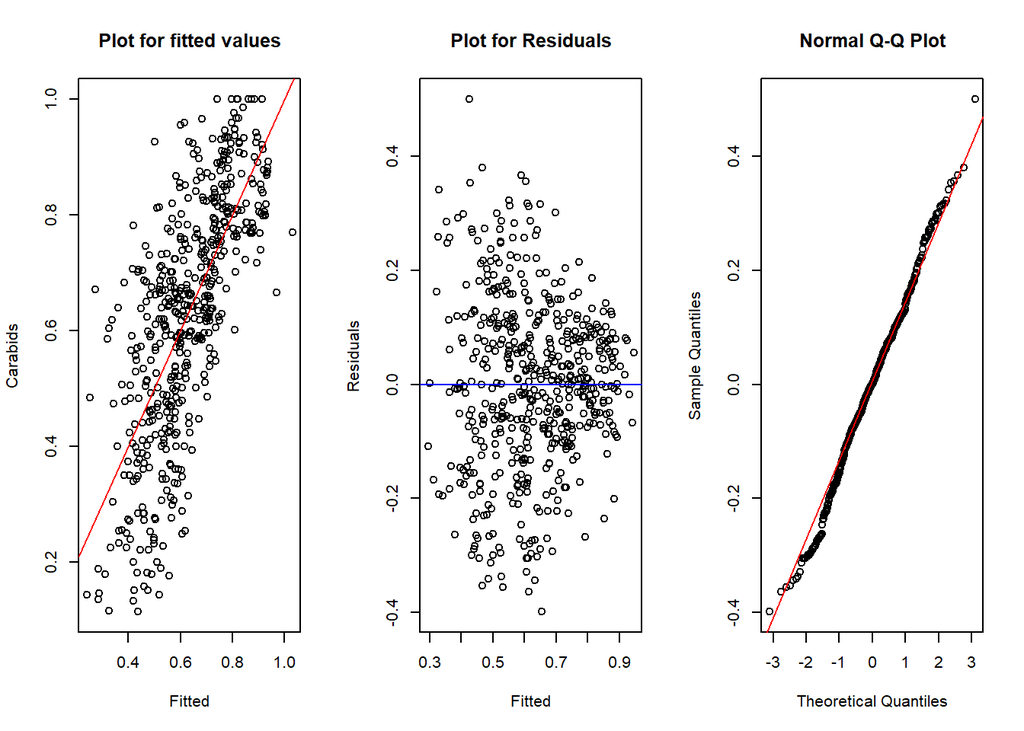

The plot for fitted values, all the data points mostly follow the line and possess few deviated values.

The plot for residuals replicates the same as the first plot.

The Q-Q plot for residuals show overlap of entire values with the line, ensured that the residuals distributed normally.

### Training Set and Test Set

In this model, the data has been splited into two data sets (training and test sets). Performed another linear regression using a training set, took Carabids as the dependent, and allocated five species as the independent.

```r
summary(tr_mod)
```

```
##
## Call:
## lm(formula = training$Carabids ~ ., data = training[c(BD5_names)],
##     y = T)
##
## Residuals:
##      Min       1Q   Median       3Q      Max
## -0.34657 -0.07658  0.00401  0.07806  0.35660
##
## Coefficients:
##                         Estimate Std. Error t value Pr(>|t|)
## (Intercept)              0.24597    0.01220  20.155  < 2e-16 ***
## Bees                     0.05114    0.01083   4.722 2.46e-06 ***
## Hoverflies               0.21899    0.01677  13.059  < 2e-16 ***
## Isopods                  0.14066    0.01444   9.740  < 2e-16 ***
## Ladybirds                0.13894    0.01220  11.387  < 2e-16 ***
## Grasshoppers_._Crickets  0.14974    0.01375  10.892  < 2e-16 ***
## ---
## Signif. codes:  0 '***' 0.001 '**' 0.01 '*' 0.05 '.' 0.1 ' ' 1
##
## Residual standard error: 0.1136 on 2634 degrees of freedom
## Multiple R-squared:  0.4393, Adjusted R-squared:  0.4383
## F-statistic: 412.8 on 5 and 2634 DF,  p-value: < 2.2e-16
```

The obtained overall p-value is smaller than the significant level, and the adjusted R-squared value is 0.4383. Then, I made a prediction to the test set with the help of training set result.

```r
mean((training$Carabids - tr_mod$fitted.values)^2)  # MSE on train data set
```

```
## [1] 0.012876
```

```r
mean((test$Carabids-predict_Y00)^2)  # MSE on test data (higher)
```

```
## [1] 0.05635688
```

Afterthat, the mean squared error (MSE) calculated and compared for the training set’s residuals and the predicted model’s residuals.

The lower MSE of the trained set is an indication of better fit to the model, and the higher MSE of the predicted model is an indication of worst performance. In this case, the predicted model’s MSE (0.05635688) is higher than the trained set (0.012876). Hence, the trained model fitted better.

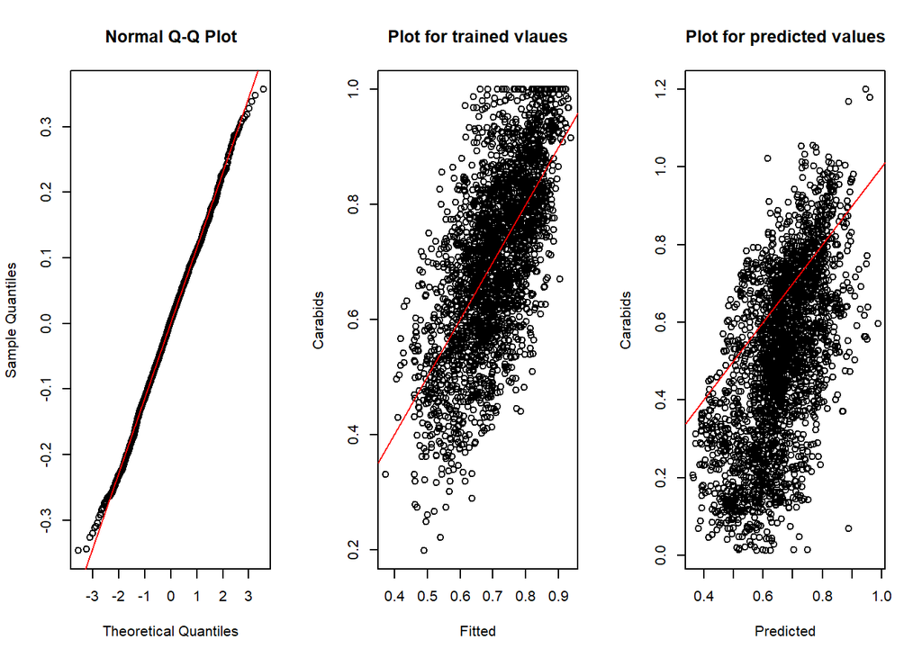

The Q-Q plot for residuals clearly show the residuals distributed evenly.

The plot for trained model indicates that all values follow the line along with few deviated values (extrem values) and imply the robust relationship between actual value and fitted value.

The plot for predicted model, all the data points are not evenly close to the line. And it densly spread far away from the line.

### Open Analysis

In open analysis, I have taken my allocated species as the dependent variable and land classification as the independent variable. The data has been classified for specific locations which are filtered by period (Y70 – Earlier Period) in Scotland.

```r
summary(open_analysis)
```

```
##
## Call:
## lm(formula = eco_status_5 ~ dominantLandClass, data = BD2, y = T)
##
## Residuals:
##      Min       1Q   Median       3Q      Max
## -0.36001 -0.09966 -0.00523  0.08974  0.47786
##
## Coefficients:
##                      Estimate Std. Error t value Pr(>|t|)
## (Intercept)           0.68086    0.02535  26.856  < 2e-16 ***
## dominantLandClass18s -0.19195    0.03341  -5.745 1.25e-08 ***
## dominantLandClass19s -0.12777    0.03618  -3.531 0.000434 ***
## dominantLandClass21s -0.14498    0.02941  -4.930 9.79e-07 ***
## dominantLandClass22s -0.16049    0.02850  -5.630 2.40e-08 ***
## dominantLandClass23s -0.08566    0.03273  -2.617 0.009012 **
## dominantLandClass24s -0.11392    0.03105  -3.669 0.000258 ***
## dominantLandClass25s -0.09335    0.02848  -3.278 0.001084 **
## dominantLandClass26s -0.02565    0.02966  -0.865 0.387252
## dominantLandClass27s -0.10471    0.03203  -3.270 0.001117 **
## dominantLandClass28s -0.19634    0.03105  -6.323 4.01e-10 ***
## dominantLandClass29s -0.26117    0.02915  -8.960  < 2e-16 ***
## dominantLandClass30s -0.14644    0.02941  -4.980 7.63e-07 ***
## dominantLandClass31s -0.09478    0.03203  -2.960 0.003161 **
## dominantLandClass32s -0.29563    0.03618  -8.170 1.03e-15 ***
## dominantLandClass7s  -0.10171    0.03987  -2.551 0.010912 *
## ---
## Signif. codes:  0 '***' 0.001 '**' 0.01 '*' 0.05 '.' 0.1 ' ' 1
##
## Residual standard error: 0.1342 on 909 degrees of freedom
## Multiple R-squared:  0.211,  Adjusted R-squared:  0.198
## F-statistic:  16.2 on 15 and 909 DF,  p-value: < 2.2e-16
```

```r
cor(open_analysis$fitted.values, open_analysis$y)
```

```
## [1] 0.4593219
```

The obtained overall p-value is smaller than the significant level (0.05), and the adjusted R-squared value is 0.198. And it has a moderate positive correlation of 0.4593219. Individual p-value for some specific land types being larger than the significant level and suggests that the existence of my allocated species is not significant in those places.

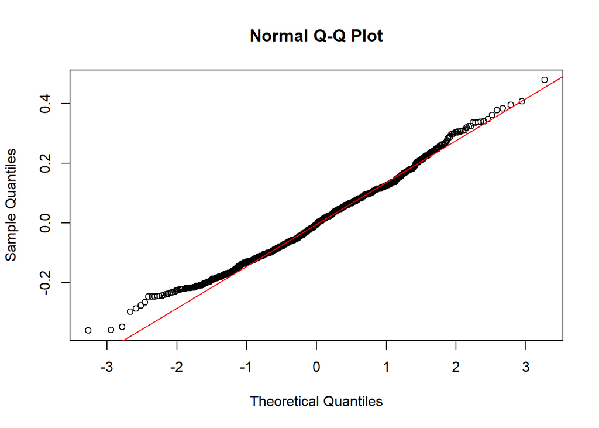

The residual values on the Q-Q plot didn’t normally distributed.

# ————————————————————————-